# Ejercicio 1

## David Montero Loaiza

### Problema 1

Generar una muestra de tamaño N = 10000 correspondiente a la altura de personas adultas, asumiendo que su densidad de probabilidad es una función normal/gaussiana con mu = 1.78m y sigma = 0.1 m.

```r
# PARAMETROS PARA GENERAR UN VECTOR ALEATORIO GAUSSIANO
N = 10000
mu = 1.78
sigma = 0.1

# MUESTRA DE TAMANO N
mN = rnorm(N,mu,sigma)
```

Dibuja la densidad de frecuencia y la densidad de probabilidad por separado.

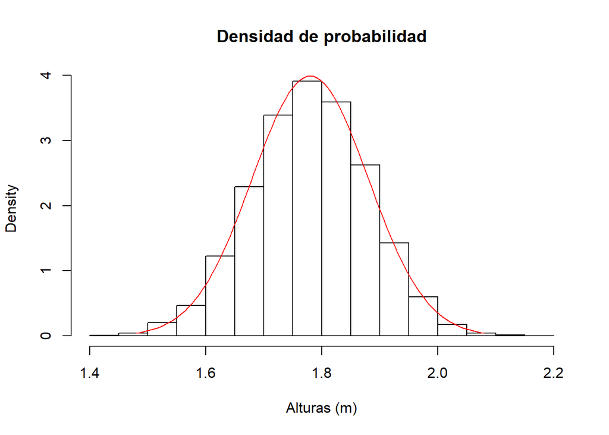

```r
# DENSIDAD DE FRECUENCIA
hist(mN,freq = FALSE,main = "Densidad de probabilidad",xlab = "Alturas (m)")

# DENSIDAD DE PROBABILIDAD
curve(dnorm(x,mu,sigma),mu - 3*sigma,mu + 3*sigma,col = "red",main = "PDF",xlab = "Alturas (m)",add = TRUE)
```

Compara mu y sigma con la media muestral y la varianza muestral.

```r
# MEDIA MUESTRAL
X = mean(mN)

# VARIANZA MUESTRAL
V = var(mN)

# COMPARACION
df = data.frame("Descripcion_M" = c("mu","Media Muestral"),
                "Media" = c(mu,X),
                "Descripcion_V" = c("sigma^2","Varianza Muestral"),
                "Varianza" = c(sigma^2,V))

df
```

| Descripcion_M | Media | Descripcion_V | Varianza |
| --- | --- | --- | --- |
| mu | 1.780000 | sigma^2 | 0.0100000 |
| Media Muestral | 1.779945 | Varianza Muestral | 0.0099654 |

Se puede apreciar que mu y la media muestral, al igual que sigma^2 y la varianza muestral, son muy aproximadas.

### Problema 2

Considerar la distribución de probabilidad anterior y la media muestral para una muestra de tamaño N (TN). Generar un número alto M = 10000 de muestras.

```r
# TAMANOS DE MUESTRA
N = c(10,100,1000,10000)

# MUESTRAS
M = 10000

# LISTA PARA ALMACENAR MEDIAS DE PSEUDO-MUESTRAS
meanList = list()

# VECTOR NULO PARA ALMACENAR MEDIAS
meanVector_mean = NULL

# VECTOR NULO PARA ALMACENAR VARIANZAS
varVector_mean = NULL

for(i in 1:length(N)){

    # GENERAR PSEUDO-MUESTRAS
    PseudoMuestras = matrix(rnorm(M*N[i],mu,sigma),M,N[i])

    # MEDIAS DE CADA MUESTRA
    means = apply(PseudoMuestras,1,mean)

    # ALMACENAR MEDIAS POR CADA MUESTRA
    meanList[[i]] = means

    # VECTOR DE MEDIAS
    meanVector_mean = c(meanVector_mean,mean(means))

    # VECTOR DE VARIANZAS
    varVector_mean = c(varVector_mean,var(means))

}
```

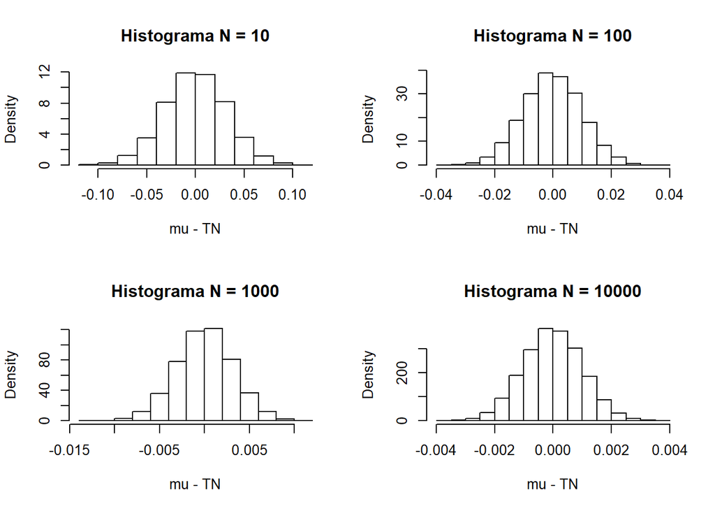

```r
# GRAFICAS DE LA DISTRIBUCION mu - TN
par(mfrow = c(2,2))

for(i in 1:length(meanList)){

  # CALCULAR mu - TN PARA CADA TAMANO DE MUESTRA
  muTn = mu - meanList[[i]]

  # GRAFICAR LA DISTRIBUCION
  hist(muTn,freq = FALSE,main = paste("Histograma N =",N[i]),xlab = "mu - TN")

}
```

Al aumentar el tamaño de las muestras el sesgo se concentra en 0 y se aprecia cómo la varianza va disminuyendo, pues la campana empieza a adelgazarse y a aumentar en densidad alrededor de 0. Esto demuestra que la media es un estimador no sesgado y consistente.

Calcular el valor esperado en cada caso (considerando el valor esperado como el promedio a los M = 10000 psuedo-experimentos) y dibujar el resultado en función de N. Repetir el mismo procedimiento usando la varianza (considerando de nuevo las las M = 10000 pseudo-muestras).

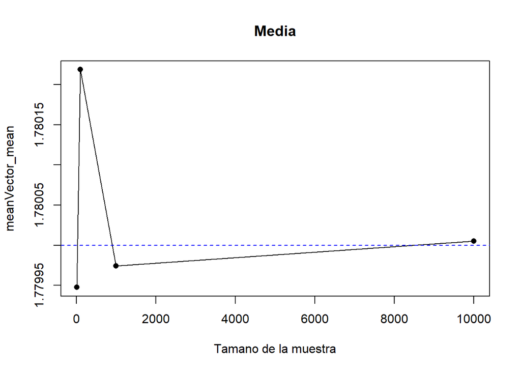

```r
# GRAFICA DE LA MEDIA EN FUNCION DE N
plot(N,meanVector_mean,type = "l",main = "Media",xlab = "Tamano de la muestra")
points(N,meanVector_mean,pch = 16)
abline(h = mu,lty = 2,col = "blue")
```

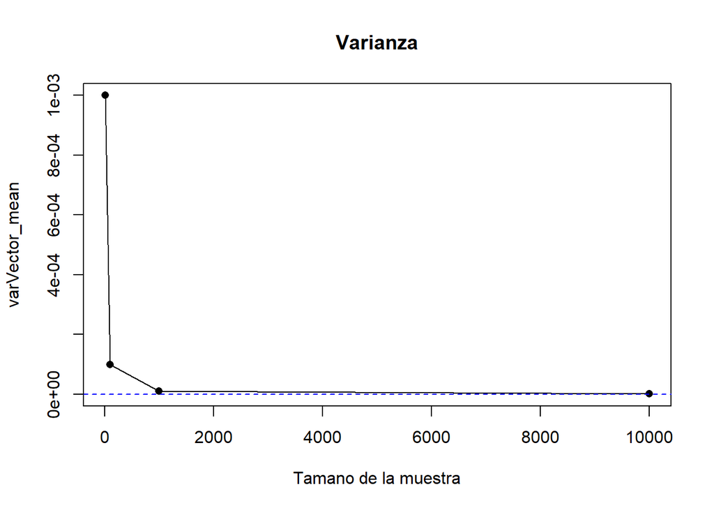

```r
# GRAFICA DE LA VARIANZA EN FUNCION DE N
plot(N,varVector_mean,type = "l",main = "Varianza",xlab = "Tamano de la muestra")
points(N,varVector_mean,pch = 16)
abline(h = 0,lty = 2,col = "blue")
```

Con las anteriores gráficas se demuestra que la media es un estimador consistente, puesto que su valor esperado se mueve alrededor de mu y su varianza tiende a ser cero cuando N tiende al infinito.

### Problema 3

Considerar la distribución de probabilidad anterior y la fórmula sesgada de la varianza. Generar un número alto de M = 10000 de muestras.

```r
# LISTA PARA ALMACENAR MEDIAS DE PSEUDO-MUESTRAS
varList = list()

# VECTOR NULO PARA ALMACENAR MEDIAS
meanVector_var = NULL

# VECTOR NULO PARA ALMACENAR VARIANZAS
varVector_var = NULL

# FUNCION PARA LA VARIANZA SESGADA
biasedVar = function(x){

  # VARIANZA SESGADA
  bV = sum((mean(x) - x)^2)/length(x)

  # RETORNAR VARIANZA SESGADA
  return(bV)

}

for(i in 1:length(N)){

    # GENERAR PSEUDO-MUESTRAS
    PseudoMuestras = matrix(rnorm(M*N[i],mu,sigma),M,N[i])

    # VARIANZAS SESGADAS DE CADA MUESTRA
    vars = apply(PseudoMuestras,1,biasedVar)

    # ALMACENAR VARIANZAS POR CADA MUESTRA
    varList[[i]] = vars

    # VECTOR DE MEDIAS
    meanVector_var = c(meanVector_var,mean(vars))

    # VECTOR DE VARIANZAS
    varVector_var = c(varVector_var,var(vars))

}
```

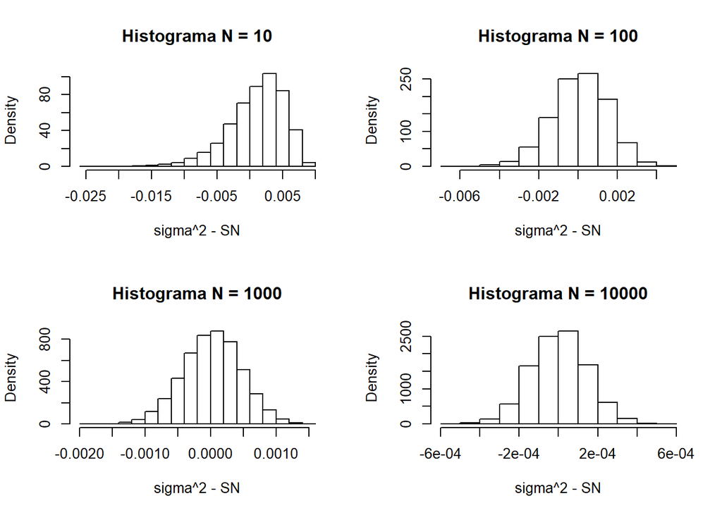

```r
# GRAFICAS DE LA DISTRIBUCION sigma^2 - SN
par(mfrow = c(2,2))

for(i in 1:length(meanList)){

  # CALCULAR sigma^2 - SN PARA CADA TAMANO DE MUESTRA
  sigmaSn = sigma^2 - varList[[i]]

  # GRAFICAR LA DISTRIBUCION
  hist(sigmaSn,freq = FALSE,main = paste("Histograma N =",N[i]),xlab = "sigma^2 - SN")

}
```

Se aprecia que la varianza se encuentra sesgada, ya que se encuentra centrada en $sesgo = -Var[X]/N$, pero al N tender hacia el infinito el sesgo tiende a ser cero. De igual manera, la varianza empieza a disminuir, por lo tanto es un estimador consistente.

Calcular el valor esperado en cada caso (usando de nuevo la media muestral) y dibujar el resultado en función de N. Se trata de un estimador consistente?

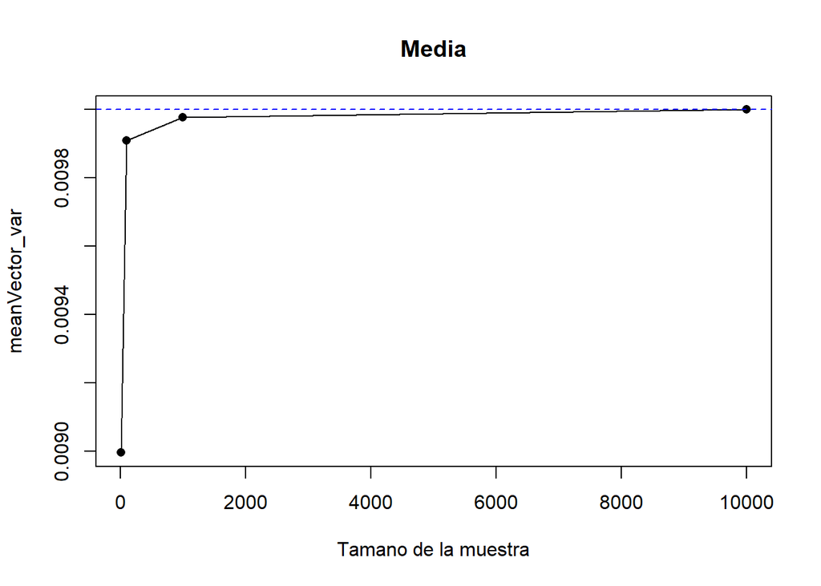

```r
# GRAFICA DE LA MEDIA EN FUNCION DE N
plot(N,meanVector_var,type = "l",main = "Media",xlab = "Tamano de la muestra")
points(N,meanVector_var,pch = 16)
abline(h = sigma^2,lty = 2,col = "blue")
```

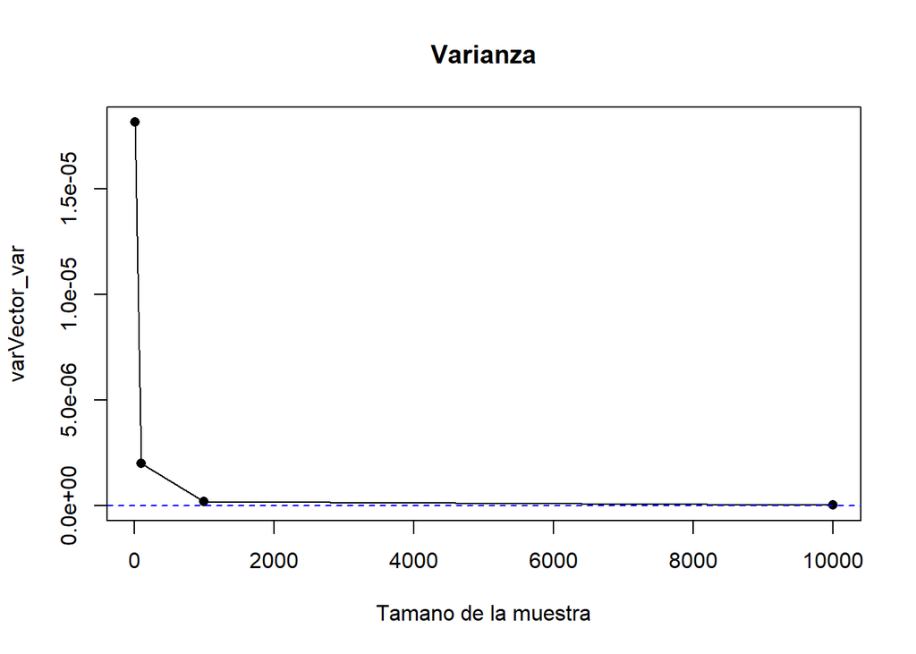

```r
# GRAFICA DE LA VARIANZA EN FUNCION DE N
plot(N,varVector_var,type = "l",main = "Varianza",xlab = "Tamano de la muestra")
points(N,varVector_var,pch = 16)
abline(h = 0,lty = 2,col = "blue")
```

La varianza calculada con la fórmula sesgada es un estimador consistente, ya que su valor esperado tiende a ser sigma^2 y su varianza tiende a ser 0.

### Problema 4

Repetir 2) utilizando la mediana en lugar de la media. Cuál de los dos estimadores es más eficiente?

```r
# LISTA PARA ALMACENAR MEDIAS DE PSEUDO-MUESTRAS
medianList = list()

# VECTOR NULO PARA ALMACENAR MEDIAS (MEDIANA)
meanVector_median = NULL

# VECTOR NULO PARA ALMACENAR VARIANZAS (MEDIANA)
varVector_median = NULL

# VECTOR NULO PARA ALMACENAR MEDIAS (MEDIA)
meanVector_mean = NULL

# VECTOR NULO PARA ALMACENAR VARIANZAS (MEDIA)
varVector_mean = NULL

for(i in 1:length(N)){

    # GENERAR PSEUDO-MUESTRAS
    PseudoMuestras = matrix(rnorm(M*N[i],mu,sigma),M,N[i])

    # MEDIANAS DE CADA MUESTRA
    medians = apply(PseudoMuestras,1,median)

    # MEDIAS DE CADA MUESTRA
    means = apply(PseudoMuestras,1,mean)

    # ALMACENAR MEDIAS POR CADA MUESTRA
    medianList[[i]] = medians

    # VECTOR DE MEDIAS (MEDIANA)
    meanVector_median = c(meanVector_median,mean(medians))

    # VECTOR DE VARIANZAS (MEDIANA)
    varVector_median = c(varVector_median,var(medians))

    # VECTOR DE MEDIAS (MEDIA)
    meanVector_mean = c(meanVector_mean,mean(means))

    # VECTOR DE VARIANZAS (MEDIA)
    varVector_mean = c(varVector_mean,var(means))

}
```

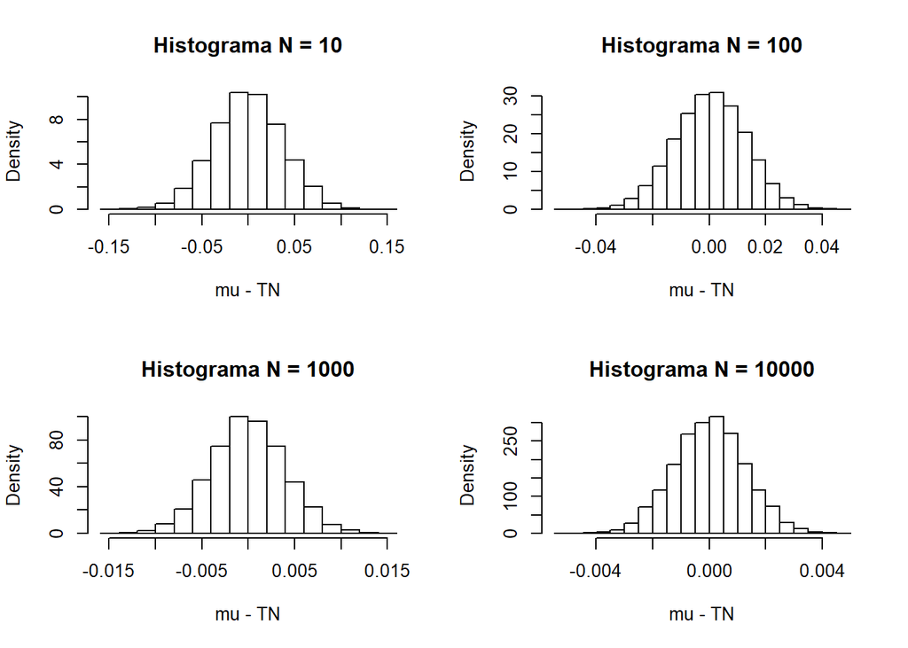

```r
# GRAFICAS DE LA DISTRIBUCION mu - TN
par(mfrow = c(2,2))

for(i in 1:length(medianList)){

  # CALCULAR mu - TN PARA CADA TAMANO DE MUESTRA
  muTn = mu - medianList[[i]]

  # GRAFICAR LA DISTRIBUCION
  hist(muTn,freq = FALSE,main = paste("Histograma N =",N[i]),xlab = "mu - TN")

}
```

Al igual que la media, la mediana es un estimador no sesgado y consistente.

Calcular el valor esperado en cada caso (considerando el valor esperado como el promedio a los M = 10000 psuedo-experimentos) y dibujar el resultado en función de N. Repetir el mismo procedimiento usando la varianza (considerando de nuevo las las M = 10000 pseudo-muestras).

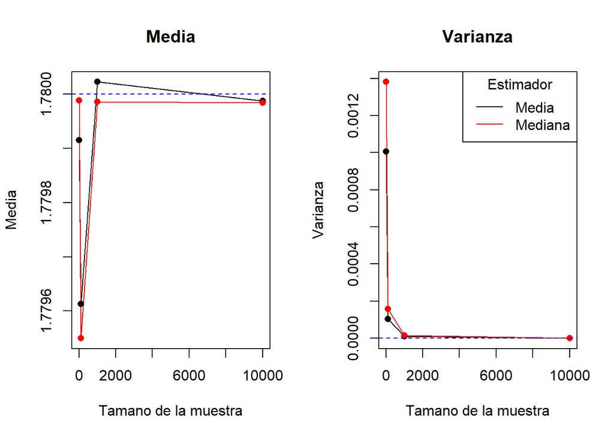

```r
# PARAMETROS PARA GRAFICAS
meanMin = min(c(meanVector_mean,meanVector_median))
meanMax = max(c(meanVector_mean,meanVector_median))
varMax = max(c(varVector_mean,varVector_median))
par(mfrow = c(1,2))

# GRAFICA DE LA MEDIA EN FUNCION DE N
plot(N,meanVector_mean,
     type = "l",
     main = "Media",
     xlab = "Tamano de la muestra",
     ylab = "Media",
     ylim = c(meanMin,meanMax))

lines(N,meanVector_median,type = "l",col = "red")
points(N,meanVector_mean,pch = 16)
points(N,meanVector_median,pch = 16,col = "red")
abline(h = mu,lty = 2,col = "blue")

# GRAFICA DE LA VARIANZA EN FUNCION DE N
plot(N,varVector_mean,
     type = "l",
     main = "Varianza",
     xlab = "Tamano de la muestra",
     ylab = "Varianza",
     ylim = c(0,varMax))

lines(N,varVector_median,type = "l",col = "red")
points(N,varVector_mean,pch = 16)
points(N,varVector_median,pch = 16,col = "red")
abline(h = 0,lty = 2,col = "blue")

legend("topright",
       legend = c("Media","Mediana"),
       col = c("black","red"),
       lwd = 1,
       title = "Estimador")
```

Según las gráficas anteriores, la varianza de la mediana tiende a ser más alta que la varianza de la media, por tal motivo la media es un estimador más eficiente que la mediana.